# Stationarity of Electricity Consumption Data in Turkey over 2016-2021

Yusuf Ulucoban

31 05 2021

# Introduction

In this study, the electricity consumption of Turkey will be aimed to be understand with its details. The data is taken from the [EPIAS](https://seffaflik.epias.com.tr/transparency/) website as hourly data from Jan 2016 to May 2021. The aim of the study is performing tasks that are given, building an ARIMA model to predictions and comparing test results for 14 days from 6th of May to 20th of May in 2021.  
To serve this aim, the time series data will repeatedly be analyzed by plotting and useful tests. Firstly, the data should be stationary. However, the electricity consumption data is non-stationary. Hence, the first task will be the transforming that data from non-stationary to stationary one. To make this transformation, differencing, decomposition, deseasonalizm and further analyses will be needed. Explanations and furher calculations will be provided in the next chapters. Right after reaching the stationary data, forecasts will be made by using Moving Average and Auto Regressive models. Also, the tasks will be performed.

# Data Manipulation and Visualization

After importing the data from the website, it is transformed to data table form and manuplations are done about it such as converting date column to date variable. Also, new data table is created to analyze daily data and average of the consumptions are added.

```r
head(elecdt,10)
```

```
##           Date Hour Consumption
##  1: 2016-01-01    0    26277.24
##  2: 2016-01-01    1    24991.82
##  3: 2016-01-01    2    23532.61
##  4: 2016-01-01    3    22464.78
##  5: 2016-01-01    4    22002.91
##  6: 2016-01-01    5    21957.08
##  7: 2016-01-01    6    22203.54
##  8: 2016-01-01    7    21844.16
##  9: 2016-01-01    8    23094.73
## 10: 2016-01-01    9    25202.27
```

```r
head(elecdt_daily,10)
```

```
##           Date Consumption
##  1: 2016-01-01    27028.72
##  2: 2016-01-02    29275.35
##  3: 2016-01-03    28560.54
##  4: 2016-01-04    33121.03
##  5: 2016-01-05    33197.91
##  6: 2016-01-06    32634.51
##  7: 2016-01-07    32534.77
##  8: 2016-01-08    32314.02
##  9: 2016-01-09    31196.08
## 10: 2016-01-10    28140.62
```

Since visualizing a hourly data for 5 years does not seems optimal, the daily data is plotted for visualizations.

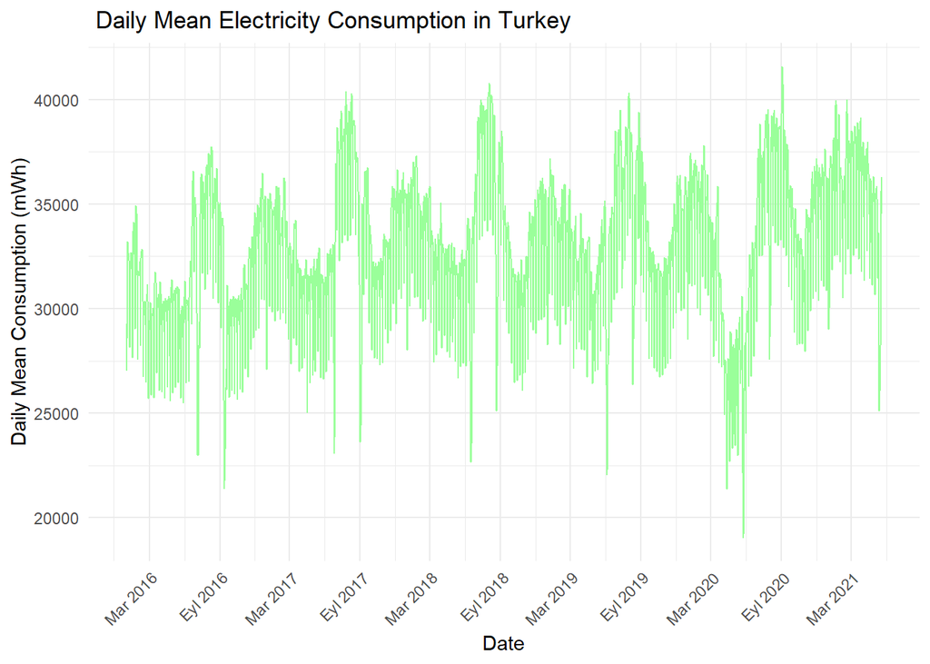

As expected, seasonal trends such as higher consumption in summers and lower in winters and temporary changes in consumption such as Covid-19 pandemic in 2020 March are obvious.

# Seek for Stationary Data

To make sure that data is non-stationary and has seasonal increases and decreases, applying unit root test would be wise.  
Unit root test will test if the consumption is stationary or not. The null hypothesis claims that; the data is stationary. So, it is expected that our data set will reject the null hypothesis.

ACF and PACF are calculated for daily data.

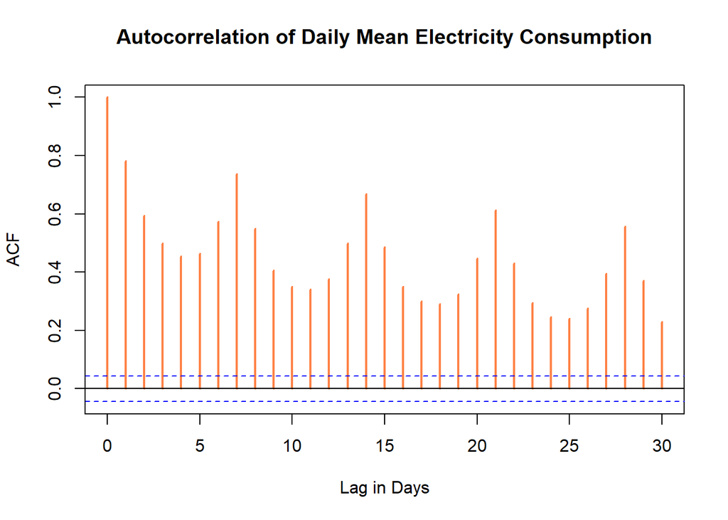

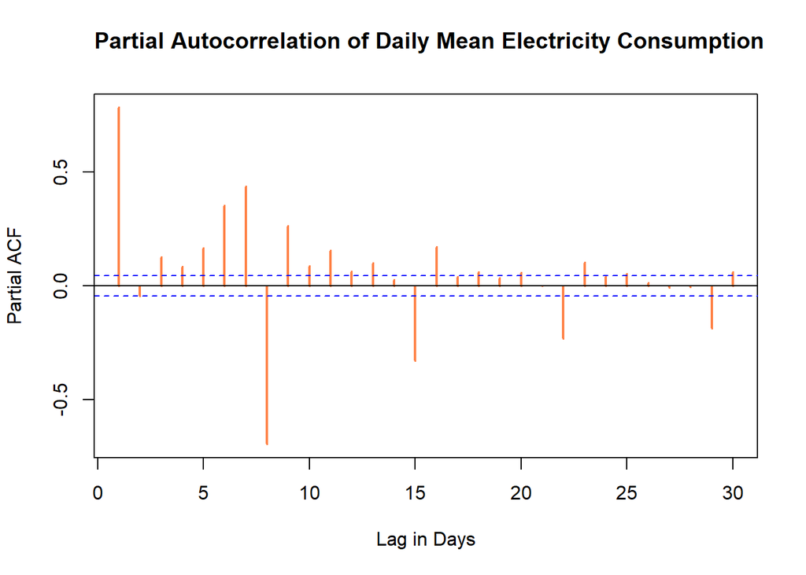

It is obvious that there is a pattern that repeats every week with lag value equals 7.  
For Unit Root test;

```
##
## #######################
## # KPSS Unit Root Test #
## #######################
##
## Test is of type: mu with 8 lags.
##
## Value of test-statistic is: 1.8597
##
## Critical value for a significance level of:
##                 10pct  5pct 2.5pct  1pct
## critical values 0.347 0.463  0.574 0.739
```

Since the seasonality is clear and also, comparison of unit root test value and critical value is showed that the daily electricity consumption data is non-stationary. For further calculations, the data is needed to be stationary.  
To reach more stationary data, let’s calculate differenced one and its ACF, PACF, Unit Root Test Value.

```r
elecdt_daily[,lag1:=shift(elecdt_daily$Consumption,1)]
elecdt_daily[,lag7:=shift(elecdt_daily$Consumption,7)]
elecdt_daily[,diff1and7:=elecdt_daily$Consumption-0.45*lag7-0.55*lag1]
```

This data manipulation part with lagging and differencing is highly important. Firstly, the data is lagged with value equals 1 because of the highest ACF and PACF values. Also, the value is lagged with value equals 7 because 7 has the second highest ACF and PACF. In the, 0.45 and 0.55 part, these values are chosen heuristic because of the their ACF and PACF values and their comparison such as PACF 7 is lower than PACF 1 and gets smaller in each week.  
With that formulation, it is possible to say that each day will carry the effect of yesterday with approximately 0.55 and two days ago with approximately 0.55 * 0.55 = 0.30. Also, each day will carry the effect of the same day in the last week with approximately 0.45 and one more week ago with approximately 0.45 * 0.45 = 0.20. *However, it is important not to forget that this approach includes highly analogical touch.*

For further steps and corrections let’s plot the differenced data.

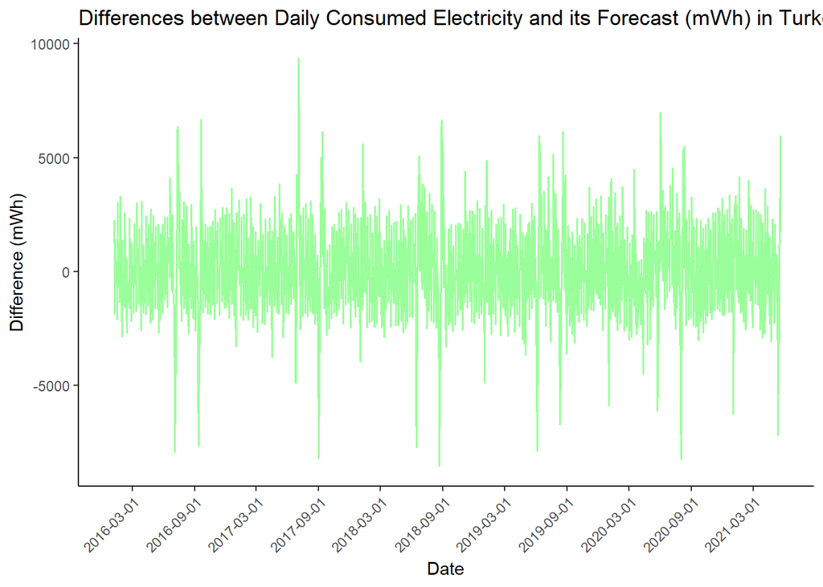

Now, the data seems more escaped from seasonalities with 0 mean. However, there is still outliers that may be occurred in national and religious holidays in which consumption levels get considerably lowered. For exact results, the differences that are plotted should distributed normally with 0 mean which is easy to control.

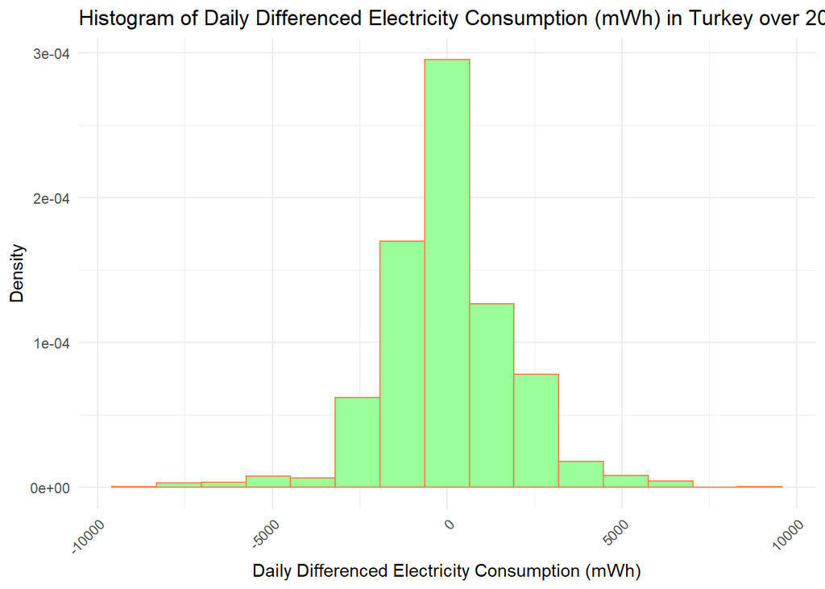

Also, it is possible that check ACF and PACF values of differenced data.

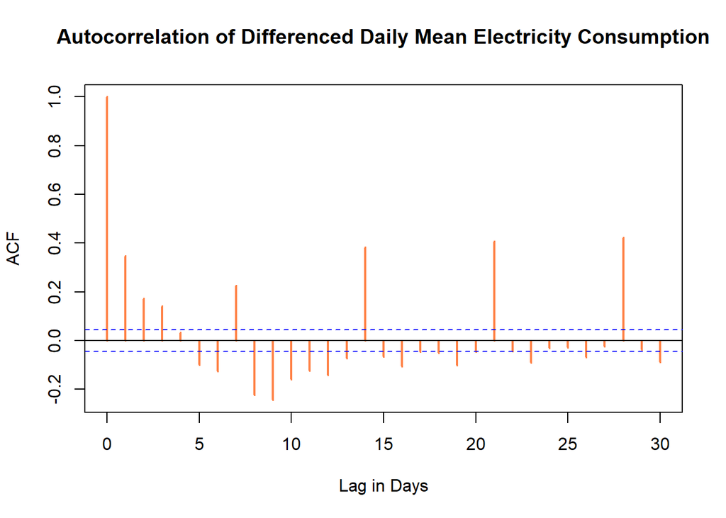

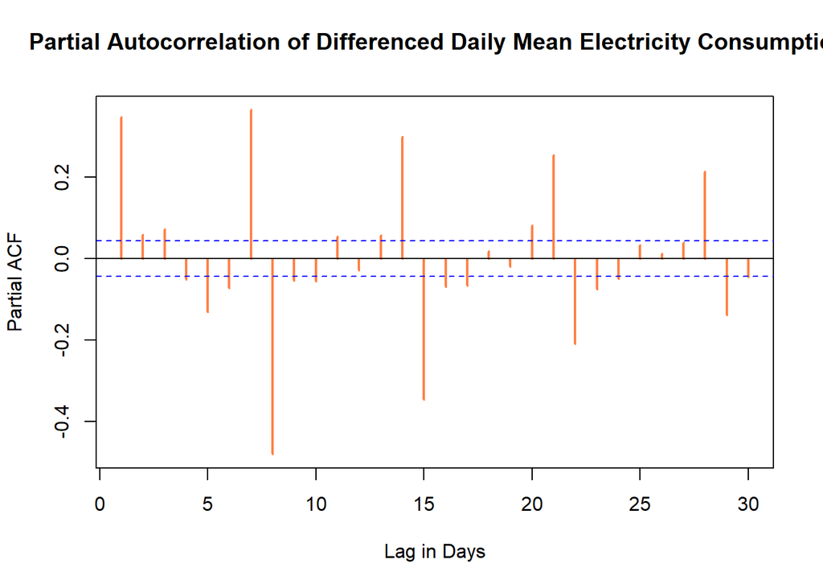

Although there is still weekly seasonalities and effects of each yesterdays, values are way better than the previous values. For a last step to conclude the data is stationary, let’s apply unit root test.

```
##
## #######################
## # KPSS Unit Root Test #
## #######################
##
## Test is of type: mu with 8 lags.
##
## Value of test-statistic is: 0.0099
##
## Critical value for a significance level of:
##                 10pct  5pct 2.5pct  1pct
## critical values 0.347 0.463  0.574 0.739
```

The value of the test-statistic is decreased from 1.8597 to 0.0099 which proves that our data is now stationary and appropriate to move on.

# Time Series Decomposition

Firstly, the time series object is created to utilize the ts function, decompose. In order to decrease weekly effect more, ts object is constructed with frequency 7.

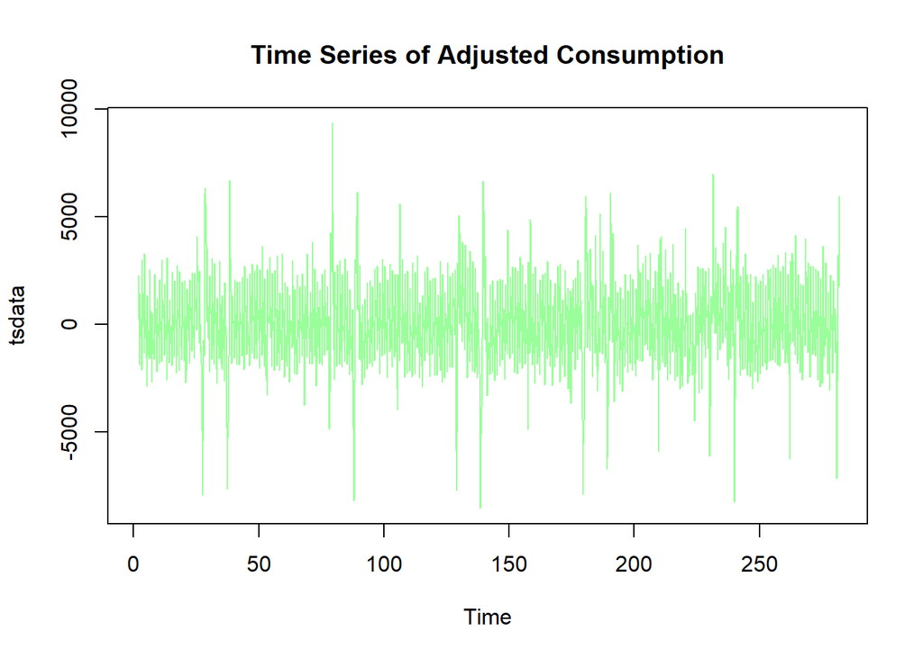

Above, you can see the ts plot of adjusted consumption. When we examine the plot, we can say that variance does not increases over time. Therefore, we prefer to use additive decomposition instead of multiplicative decomposition method.

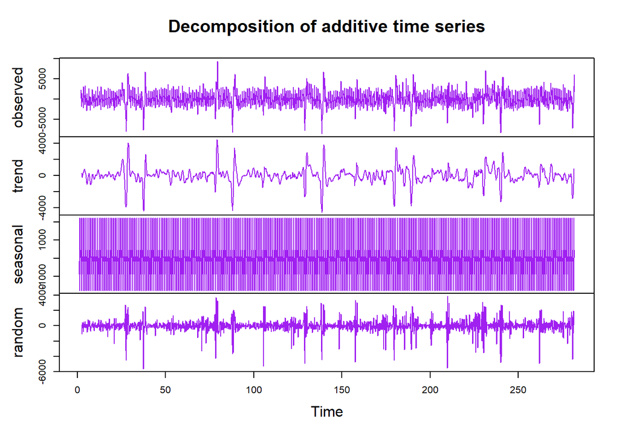

Above, you can see additive decomposition of adjusted consumption. By looking the random part, we can say there are still outliers that are caused by special days such as holidays and public days. However, since our adjusted data is stationary enough, it will be enough to clear our ts object from seasonality and trend. However, these outliers affects trend plot with a little seasonality. with 2 peeks for each. The first one is for “Ramazan” and the second one is for “Kurban” holidays. These two may affect our model but the details will be investigated in further parts.

### Reducing Outliers

In this part, it will be mentioned that, the outliers in the data are able to be reduced, even removed. The method for that calculations will be mentioned but will not be applied. To reduce and even remove outliers is possible by creating a new variable for each day that shows that the day is national or religious holiday. Also, further calculations are easy to be achieved by creating another diff1and7 for “elecdt_daily” data with values of new column.  
*However, because the t-value in Unit Root Test and distribution type of data is enough to claim that the data is stationary, these steps will not be applied.*

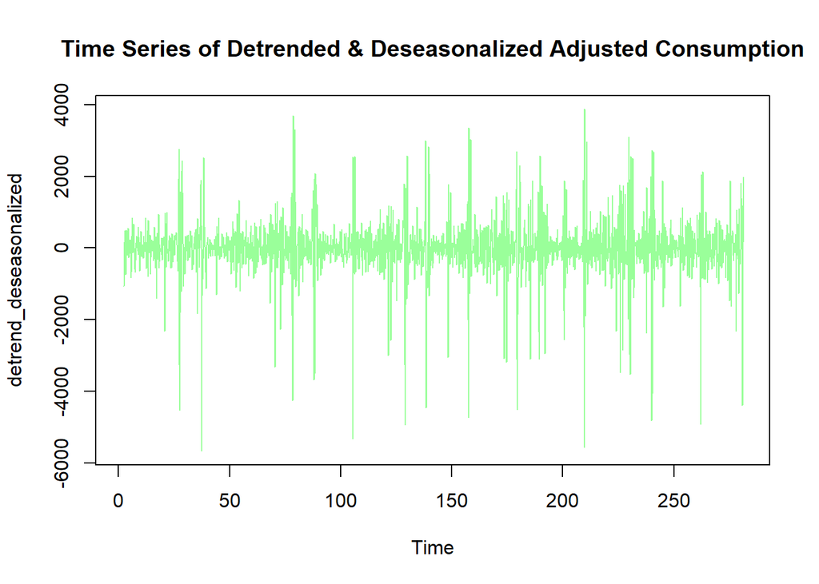

Above you can see the detrended and deseasonalized adjusted consumption which will be named as normal of consumption in the remaining part of the study.

Let’s look at the Unit Root Test results to make sure that the data that is calculated from decompositions is still stationary.

```
##
## #######################
## # KPSS Unit Root Test #
## #######################
##
## Test is of type: mu with 8 lags.
##
## Value of test-statistic is: 0.0031
##
## Critical value for a significance level of:
##                 10pct  5pct 2.5pct  1pct
## critical values 0.347 0.463  0.574 0.739
```

According to the KPSS Unit Root Test results, our test-statistic value 0.0031 is less than our last test results 0.0099 and still smaller than the critical values 0.347.

Finally, let’s take a look at our ts object, which we will put in the arima model, in detail and then set up our model.

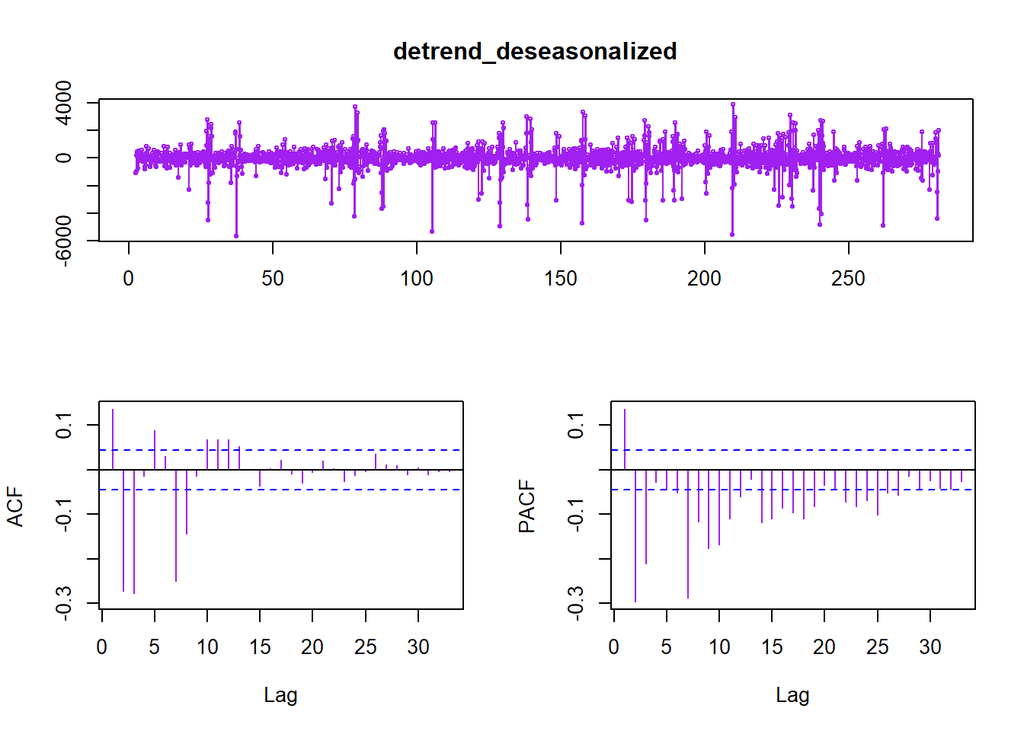

Since our ACF / PACF graphics and our detrend & deseasonalized plot are suitable for stationarity, we can move on to the model selection part with arima.

# AR Models for Normal of Consumption

```
##
## Call:
## arima(x = detrend_deseasonalized, order = c(1, 0, 0))
##
## Coefficients:
##          ar1  intercept
##       0.1361    -1.4344
## s.e.  0.0224    21.4043
##
## sigma^2 estimated as 668254:  log likelihood = -15876.55,  aic = 31759.11
```

```
##
## Call:
## arima(x = detrend_deseasonalized, order = c(2, 0, 0))
##
## Coefficients:
##          ar1      ar2  intercept
##       0.1762  -0.2971    -1.4470
## s.e.  0.0216   0.0216    15.7593
##
## sigma^2 estimated as 609421:  log likelihood = -15786.61,  aic = 31581.21
```

```
##
## Call:
## arima(x = detrend_deseasonalized, order = c(3, 0, 0))
##
## Coefficients:
##          ar1      ar2      ar3  intercept
##       0.1133  -0.2598  -0.2122    -1.4682
## s.e.  0.0221   0.0215   0.0221    12.7075
##
## sigma^2 estimated as 582012:  log likelihood = -15741.72,  aic = 31493.43
```

```
##
## Call:
## arima(x = detrend_deseasonalized, order = c(4, 0, 0))
##
## Coefficients:
##          ar1      ar2      ar3      ar4  intercept
##       0.1075  -0.2669  -0.2091  -0.0274    -1.4673
## s.e.  0.0226   0.0223   0.0223   0.0226    12.3650
##
## sigma^2 estimated as 581576:  log likelihood = -15740.98,  aic = 31493.97
```

```
##
## Call:
## arima(x = detrend_deseasonalized, order = c(5, 0, 0))
##
## Coefficients:
##          ar1      ar2      ar3      ar4      ar5  intercept
##       0.1064  -0.2753  -0.2200  -0.0231  -0.0411    -1.4548
## s.e.  0.0226   0.0227   0.0231   0.0227   0.0228    11.8684
##
## sigma^2 estimated as 580604:  log likelihood = -15739.35,  aic = 31492.71
```

```
##
## Call:
## arima(x = detrend_deseasonalized, order = c(6, 0, 0))
##
## Coefficients:
##          ar1      ar2      ar3      ar4      ar5      ar6  intercept
##       0.1043  -0.2764  -0.2308  -0.0367  -0.0363  -0.0500    -1.4069
## s.e.  0.0226   0.0227   0.0236   0.0236   0.0228   0.0228    11.2896
##
## sigma^2 estimated as 579177:  log likelihood = -15736.96,  aic = 31489.92
```

# MA Models for Normal of Consumption

```
##
## Call:
## arima(x = detrend_deseasonalized, order = c(0, 0, 1))
##
## Coefficients:
##          ma1  intercept
##       0.2255    -1.4423
## s.e.  0.0246    22.4856
##
## sigma^2 estimated as 657909:  log likelihood = -15861.33,  aic = 31728.65
```

```
##
## Call:
## arima(x = detrend_deseasonalized, order = c(0, 0, 2))
##
## Coefficients:
##           ma1      ma2  intercept
##       -0.3599  -0.6400    -0.0084
## s.e.   0.0129   0.0129     0.0495
##
## sigma^2 estimated as 564853:  log likelihood = -15715.85,  aic = 31439.71
```

```
##
## Call:
## arima(x = detrend_deseasonalized, order = c(0, 0, 3))
##
## Coefficients:
##           ma1      ma2      ma3  intercept
##       -0.1126  -0.5178  -0.3695    -0.0099
## s.e.   0.0208   0.0182   0.0183     0.0630
##
## sigma^2 estimated as 483869:  log likelihood = -15564.5,  aic = 31138.99
```

```
##
## Call:
## arima(x = detrend_deseasonalized, order = c(0, 0, 4))
##
## Coefficients:
##           ma1      ma2      ma3      ma4  intercept
##       -0.0907  -0.4648  -0.3723  -0.0723    -0.0103
## s.e.   0.0224   0.0247   0.0188   0.0247     0.0675
##
## sigma^2 estimated as 481788:  log likelihood = -15560.23,  aic = 31132.46
```

```
##
## Call:
## arima(x = detrend_deseasonalized, order = c(0, 0, 5))
##
## Coefficients:
##           ma1      ma2      ma3      ma4      ma5  intercept
##       -0.0903  -0.4650  -0.3720  -0.0722  -0.0005    -0.0101
## s.e.   0.0238   0.0248   0.0211   0.0251   0.0242     0.0676
##
## sigma^2 estimated as 481794:  log likelihood = -15560.23,  aic = 31134.46
```

```
##
## Call:
## arima(x = detrend_deseasonalized, order = c(0, 0, 6))
##
## Coefficients:
##           ma1      ma2      ma3      ma4     ma5     ma6  intercept
##       -0.2331  -0.7100  -0.6403  -0.1541  0.2552  0.4825     0.0012
## s.e.   0.0211   0.0205   0.0262   0.0256  0.0204  0.0195     0.0059
##
## sigma^2 estimated as 439667:  log likelihood = -15475.8,  aic = 30967.6
```

# Building an ARIMA Model

To find out the best fitting model, the “auto.arima” function is able to be used.

```r
fitted=auto.arima(detrend_deseasonalized, seasonal=FALSE, trace=T, max.p = 10, max.q = 10, max.P = 10, max.Q = 10)
```

```
##
##  Fitting models using approximations to speed things up...
##
##  ARIMA(2,0,2)           with non-zero mean : 31162.2
##  ARIMA(0,0,0)           with non-zero mean : 31793.62
##  ARIMA(1,0,0)           with non-zero mean : 31758.43
##  ARIMA(0,0,1)           with non-zero mean : 31728.67
##  ARIMA(0,0,0)           with zero mean     : 31791.62
##  ARIMA(1,0,2)           with non-zero mean : Inf
##  ARIMA(2,0,1)           with non-zero mean : 31160.66
##  ARIMA(1,0,1)           with non-zero mean : 31716.1
##  ARIMA(2,0,0)           with non-zero mean : 31580.33
##  ARIMA(3,0,1)           with non-zero mean : Inf
##  ARIMA(3,0,0)           with non-zero mean : 31493.43
##  ARIMA(3,0,2)           with non-zero mean : Inf
##  ARIMA(2,0,1)           with zero mean     : 31159.08
##  ARIMA(1,0,1)           with zero mean     : 31714.09
##  ARIMA(2,0,0)           with zero mean     : 31578.33
##  ARIMA(3,0,1)           with zero mean     : Inf
##  ARIMA(2,0,2)           with zero mean     : 31160.61
##  ARIMA(1,0,0)           with zero mean     : 31756.43
##  ARIMA(1,0,2)           with zero mean     : Inf
##  ARIMA(3,0,0)           with zero mean     : 31491.42
##  ARIMA(3,0,2)           with zero mean     : Inf
##
##  Now re-fitting the best model(s) without approximations...
##
##  ARIMA(2,0,1)           with zero mean     : Inf
##  ARIMA(2,0,2)           with zero mean     : Inf
##  ARIMA(2,0,1)           with non-zero mean : Inf
##  ARIMA(2,0,2)           with non-zero mean : Inf
##  ARIMA(3,0,0)           with zero mean     : 31491.47
##
##  Best model: ARIMA(3,0,0)           with zero mean
```

```
##
## Call:
## arima(x = detrend_deseasonalized, order = c(3, 0, 5))
##
## Coefficients:
##           ar1      ar2      ar3     ma1     ma2      ma3      ma4      ma5
##       -0.7262  -0.5944  -0.3366  0.6487  0.0587  -0.4975  -0.7504  -0.4594
## s.e.   0.0749   0.0618   0.0520  0.0731  0.0541   0.0486   0.0421   0.0326
##       intercept
##         -0.0097
## s.e.     0.0620
##
## sigma^2 estimated as 463815:  log likelihood = -15523.31,  aic = 31066.62
```

```
## [1] 31066.62
```

```
## [1] 31122.39
```

# Plotting the Forecast vs Actual for 14 Days

First of all, a daily forecast will be made with arima model that is prepared. Then, decomposition moves that is applied to reach stationary consumption data will be undone.  
Later, the first manipulations such as lagging the data in order to reducing effects that are shown in ACF and PACF plots, will be undone in order to reach predictions.

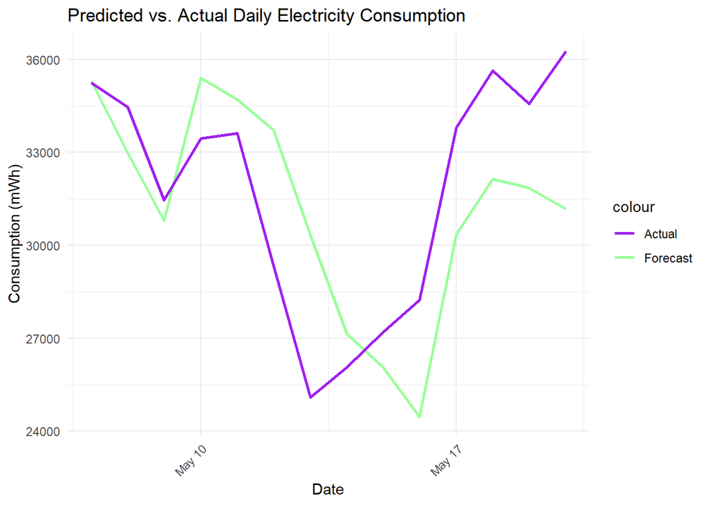

## Performance Measures (Back-Testing) for 14 Days Prediction

Testing the prediction we make as a result of the model we have set up is a feedback mechanism that shows our performance. For this reason, we compare our actual and forecasted data and look at measures such as mean, sd, error, FBias, MAPE, MAD, WMAPE.

```
##    n     mean       sd     error      FBias       MAPE      MAD      WMAPE
## 1 14 31745.47 3816.333 -50.24026 0.01805325 0.08210248 2541.054 0.08004462
```

# Plotting the Forecast vs Actual for 28 Days

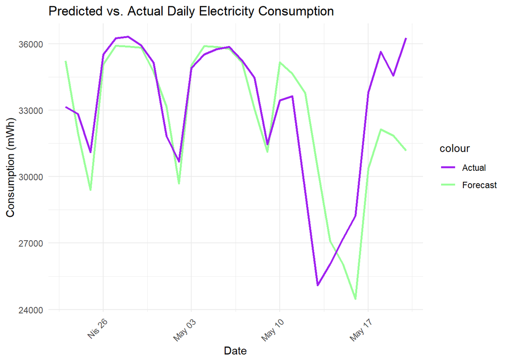

## Performance Measures (Back-Testing) for 28 Days Prediction

Comparing predictions for 14 days and 28 days would be wise. It is obvious that the second predictions will have lower errors, MADE, MAP ,WMAPE etc.

```
##    n    mean      sd     error      FBias       MAPE      MAD      WMAPE
## 1 28 33044.9 3268.82 -2074.483 0.01013114 0.05060903 1584.734 0.04795699
```

## Consideration of National and Religious Holidays

For a prediction model that will forecast an extreme model, as we had in our study, is available to be improved. There are several methods to improve.  
Firstly, the new binary column should be added that equals 1 if the day is national/religious holiday and equals 0 if not. Then, for each holidays the deviations from predictions will be noted.  
Later, while forecasting a holiday, the averages of these deviations would be used.  
However, since our model fits good enough, the further calculations will not be realized although it is not a perfect model.

# Daily Prediction with ARIMA Model for 21th May

With the same calculations that are made to predict last 14 days, the consumption of tomorrow “*21 May*” will be forecasted.

```
## Time Series:
## Start = c(282, 1)
## End = c(282, 1)
## Frequency = 7
## [1] 32674.74
```

Since forecasting with weekly trends is more accurate, the frequency of data is chosen as 7. The first data includes 47208 observations as hourly, which equals 1967 days. Also, 1967 days equals 281 weeks, that is why the result is shown as “(282,1)”.

# Sharing Out the Daily Prediction

The forecast for 21 May is already made. However, the hourly forecasts are not reached yet. To reach hourly values, each of the previous “Friday” values are taken consideration. For each Friday, the percentages of the each hour for total consumption in the day and their average are calculated.

```r
head(hourlyperc)
```

```
## # A tibble: 6 x 2
##    Hour Percantage
##   <int>      <dbl>
## 1     0       3.88
## 2     1       3.69
## 3     2       3.56
## 4     3       3.48
## 5     4       3.44
## 6     5       3.42
```

Later, the daily prediction is shared out with the hourly percentages for Fridays. Also, Actual vs. Prediction graph is plotted to compare these two.

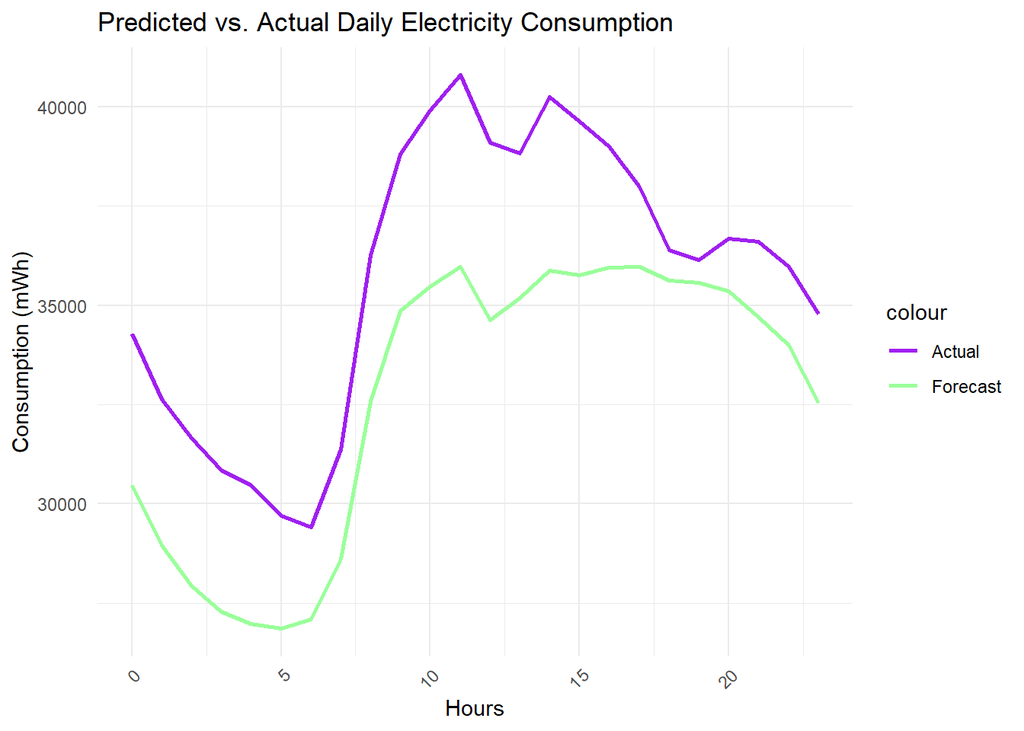

It turns out that the forecast model has some errors that may occur because of the different seasonalities data has such as hourly, daily, weekly etc.  
However, the model looks similar to the actual values enough to accept.

# Conclusion

**To reach the RMD file and the codes of this study, please [Click](https://bu-ie-360.github.io/spring21-yulucoban/files/Homework3.Rmd).**